# Análise de Personalidade de Clientes - EDA

Gleynner Ghiotto

# Atributos

- **Pessoas**:

**ID:** Identificador único do cliente  
**Year_Birth:** Ano de nascimento do cliente  
**Education:** Nível de instrução do cliente  
**Marital_Status:** Estado civil do cliente  
**Income:** Renda familiar anual do cliente  
**Kidhome:** Número de crianças na residência do cliente  
**Teenhome:** Número de adolescentes na casa do cliente  
**Dt_Customer:** Data do cadastro do cliente na empresa  
**Recency:** Quantidade de dias desde a última compra do cliente  
**Complain:** 1 se o cliente reclamou nos últimos 2 anos, 0 caso contrário

- **Produtos**:

**MntWines:** valor gasto em produtos vitivinícolas nos últimos 2 anos  
**MntFruits:** valor gasto com frutas nos últimos 2 anos  
**MntMeatProducts:** Valor gasto com carnes nos últimos 2 anos  
**MntFishProducts:** Valor gasto em produtos pesqueiros nos últimos 2 anos  
**MntSweetProducts:** Valor gasto em produtos doces nos últimos 2 anos  
**MntGoldProds:** Valor gasto em produtos de ouro nos últimos 2 anos

- **Promoção**:

**NumDealsPurchases:** Número de compras feitas com desconto  
**AcceptedCmp1:** 1 se o cliente aceitou a oferta na 1ª campanha, 0 caso contrário  
**AcceptedCmp2:** 1 se o cliente aceitou a oferta na 2ª campanha, 0 caso contrário  
**AcceptedCmp3:** 1 se o cliente aceitou a oferta na 3ª campanha, 0 caso contrário  
**AcceptedCmp4:** 1 se o cliente aceitou a oferta na 4ª campanha, 0 caso contrário  
**AcceptedCmp5:** 1 se o cliente aceitou a oferta na 1ª campanha, 0 caso contrário  
**Response:** 1 se o cliente aceitou a oferta na última campanha, 0 caso contrário

- **Local**:

**NumWebPurchases:** Número de compras feitas pelo site da empresa  
**NumCatalogPurchases:** Número de compras feitas usando um catálogo  
**NumStorePurchases:** Número de compras feitas diretamente nas lojas  
**NumWebVisitsMonth:** Número de visitas ao site da empresa no último mês

# Pré-processamento

## Examinando o conjunto de dados

```r
dados <- read.csv("marketing_campaign.csv",
                  header = TRUE, sep = "\t")
head(dados, n=10)
```

|  | ID | Year_Birth | Education | Marital_Status | Income | Kidhome | Teenhome | Dt_Customer | Recency | MntWines | MntFruits | MntMeatProducts | MntFishProducts | MntSweetProducts | MntGoldProds | NumDealsPurchases | NumWebPurchases | NumCatalogPurchases | NumStorePurchases | NumWebVisitsMonth | AcceptedCmp3 | AcceptedCmp4 | AcceptedCmp5 | AcceptedCmp1 | AcceptedCmp2 | Complain | Z_CostContact | Z_Revenue | Response |
| --- | --- | --- | --- | --- | --- | --- | --- | --- | --- | --- | --- | --- | --- | --- | --- | --- | --- | --- | --- | --- | --- | --- | --- | --- | --- | --- | --- | --- | --- |
| 1 | 5524 | 1957 | Graduation | Single | 58138 | 0 | 0 | 04-09-2012 | 58 | 635 | 88 | 546 | 172 | 88 | 88 | 3 | 8 | 10 | 4 | 7 | 0 | 0 | 0 | 0 | 0 | 0 | 3 | 11 | 1 |
| 2 | 2174 | 1954 | Graduation | Single | 46344 | 1 | 1 | 08-03-2014 | 38 | 11 | 1 | 6 | 2 | 1 | 6 | 2 | 1 | 1 | 2 | 5 | 0 | 0 | 0 | 0 | 0 | 0 | 3 | 11 | 0 |
| 3 | 4141 | 1965 | Graduation | Together | 71613 | 0 | 0 | 21-08-2013 | 26 | 426 | 49 | 127 | 111 | 21 | 42 | 1 | 8 | 2 | 10 | 4 | 0 | 0 | 0 | 0 | 0 | 0 | 3 | 11 | 0 |
| 4 | 6182 | 1984 | Graduation | Together | 26646 | 1 | 0 | 10-02-2014 | 26 | 11 | 4 | 20 | 10 | 3 | 5 | 2 | 2 | 0 | 4 | 6 | 0 | 0 | 0 | 0 | 0 | 0 | 3 | 11 | 0 |
| 5 | 5324 | 1981 | PhD | Married | 58293 | 1 | 0 | 19-01-2014 | 94 | 173 | 43 | 118 | 46 | 27 | 15 | 5 | 5 | 3 | 6 | 5 | 0 | 0 | 0 | 0 | 0 | 0 | 3 | 11 | 0 |
| 6 | 7446 | 1967 | Master | Together | 62513 | 0 | 1 | 09-09-2013 | 16 | 520 | 42 | 98 | 0 | 42 | 14 | 2 | 6 | 4 | 10 | 6 | 0 | 0 | 0 | 0 | 0 | 0 | 3 | 11 | 0 |
| 7 | 965 | 1971 | Graduation | Divorced | 55635 | 0 | 1 | 13-11-2012 | 34 | 235 | 65 | 164 | 50 | 49 | 27 | 4 | 7 | 3 | 7 | 6 | 0 | 0 | 0 | 0 | 0 | 0 | 3 | 11 | 0 |
| 8 | 6177 | 1985 | PhD | Married | 33454 | 1 | 0 | 08-05-2013 | 32 | 76 | 10 | 56 | 3 | 1 | 23 | 2 | 4 | 0 | 4 | 8 | 0 | 0 | 0 | 0 | 0 | 0 | 3 | 11 | 0 |
| 9 | 4855 | 1974 | PhD | Together | 30351 | 1 | 0 | 06-06-2013 | 19 | 14 | 0 | 24 | 3 | 3 | 2 | 1 | 3 | 0 | 2 | 9 | 0 | 0 | 0 | 0 | 0 | 0 | 3 | 11 | 1 |
| 10 | 5899 | 1950 | PhD | Together | 5648 | 1 | 1 | 13-03-2014 | 68 | 28 | 0 | 6 | 1 | 1 | 13 | 1 | 1 | 0 | 0 | 20 | 1 | 0 | 0 | 0 | 0 | 0 | 3 | 11 | 0 |

```r
cat("O Data Frame original possui", dim(dados)[1],"linhas e",
    dim(dados)[2],"colunas")
```

```
O Data Frame original possui 2240 linhas e 29 colunas
```

```r
cat("Variáveis presentes no Data Frame: \n", colnames(dados),
    "\n Total de variáveis:", length(colnames(dados)), sep = " \n ")
```

```
Variáveis presentes no Data Frame:

 ID
 Year_Birth
 Education
 Marital_Status
 Income
 Kidhome
 Teenhome
 Dt_Customer
 Recency
 MntWines
 MntFruits
 MntMeatProducts
 MntFishProducts
 MntSweetProducts
 MntGoldProds
 NumDealsPurchases
 NumWebPurchases
 NumCatalogPurchases
 NumStorePurchases
 NumWebVisitsMonth
 AcceptedCmp3
 AcceptedCmp4
 AcceptedCmp5
 AcceptedCmp1
 AcceptedCmp2
 Complain
 Z_CostContact
 Z_Revenue
 Response

 Total de variáveis:
 29
```

## Detectando valores ausentes e valores distintos

```r
df_preprocess <- dados

func_my_summary(df_preprocess)
```

| Variavel | Tipo | N | Missing | Missing_Percent | N_unique |
| --- | --- | --- | --- | --- | --- |
| ID | integer | 2240 | 0 | 0.0 | 2240 |
| Year_Birth | integer | 2240 | 0 | 0.0 | 59 |
| Education | character | 2240 | 0 | 0.0 | 5 |
| Marital_Status | character | 2240 | 0 | 0.0 | 8 |
| Income | integer | 2240 | 24 | 1.1 | 1975 |
| Kidhome | integer | 2240 | 0 | 0.0 | 3 |
| Teenhome | integer | 2240 | 0 | 0.0 | 3 |
| Dt_Customer | character | 2240 | 0 | 0.0 | 663 |
| Recency | integer | 2240 | 0 | 0.0 | 100 |
| MntWines | integer | 2240 | 0 | 0.0 | 776 |

[output cut: 19 more lines]

```r
cat("Índices dos valores ausentes da variável Income: \n",
    which(is.na(df_preprocess$Income)),
    "\n\nTotal de NA's:",
    sum(is.na(df_preprocess$Income)), sep = " " )
```

```
Índices dos valores ausentes da variável Income:
 11 28 44 49 59 72 91 92 93 129 134 313 320 1380 1383 1384 1387 2060 2062 2079 2080 2082 2085 2229

Total de NA's: 24
```

```r
# Eliminar valores NA da variável Income
df_preprocess <- df_preprocess %>% drop_na(Income)

cat("Quantidade de valores ausentes (NA) após eliminação:", sum(is.na(df_preprocess)))
```

```
Quantidade de valores ausentes (NA) após eliminação: 0
```

## Detectando valores duplicados

```r
cat("Quantidade de valores duplicados é:", sum(duplicated(df_preprocess)))
```

```
Quantidade de valores duplicados é: 0
```

## Eliminar colunas Z_CostContact e Z_Revenue (por possuir o mesmo valor em todas as observações)

```r
unique(df_preprocess$Z_CostContact) %>% length()
```

```
[1] 1
```

```r
unique(df_preprocess$Z_Revenue) %>% length()
```

```
[1] 1
```

```r
df_preprocess[,c("Z_CostContact","Z_Revenue")] <- NULL
```

# Análise Exploratória

## Estatísticas descritivas

```r
df_eda <- df_preprocess

my_summary_all(df_eda)
```

|  | ID | Year_Birth | Income | Kidhome | Teenhome | Recency | MntWines | MntFruits | MntMeatProducts | MntFishProducts | MntSweetProducts | MntGoldProds | NumDealsPurchases | NumWebPurchases | NumCatalogPurchases | NumStorePurchases | NumWebVisitsMonth | AcceptedCmp3 | AcceptedCmp4 | AcceptedCmp5 | AcceptedCmp1 | AcceptedCmp2 | Complain | Response |
| --- | --- | --- | --- | --- | --- | --- | --- | --- | --- | --- | --- | --- | --- | --- | --- | --- | --- | --- | --- | --- | --- | --- | --- | --- |
| Min | 0.00 | 1893.00 | 1730.00 | 0.00 | 0.00 | 0.00 | 0.00 | 0.00 | 0.00 | 0.00 | 0.00 | 0.00 | 0.00 | 0.00 | 0.00 | 0.00 | 0.00 | 0.00 | 0.00 | 0.00 | 0.00 | 0.00 | 0.00 | 0.00 |
| Q1 | 2814.75 | 1959.00 | 35303.00 | 0.00 | 0.00 | 24.00 | 24.00 | 2.00 | 16.00 | 3.00 | 1.00 | 9.00 | 1.00 | 2.00 | 0.00 | 3.00 | 3.00 | 0.00 | 0.00 | 0.00 | 0.00 | 0.00 | 0.00 | 0.00 |
| Mediana | 5458.50 | 1970.00 | 51381.50 | 0.00 | 0.00 | 49.00 | 174.50 | 8.00 | 68.00 | 12.00 | 8.00 | 24.50 | 2.00 | 4.00 | 2.00 | 5.00 | 6.00 | 0.00 | 0.00 | 0.00 | 0.00 | 0.00 | 0.00 | 0.00 |
| Media | 5588.35 | 1968.82 | 52247.25 | 0.44 | 0.51 | 49.01 | 305.09 | 26.36 | 167.00 | 37.64 | 27.03 | 43.97 | 2.32 | 4.09 | 2.67 | 5.80 | 5.32 | 0.07 | 0.07 | 0.07 | 0.06 | 0.01 | 0.01 | 0.15 |
| Q3 | 8421.75 | 1977.00 | 68522.00 | 1.00 | 1.00 | 74.00 | 505.00 | 33.00 | 232.25 | 50.00 | 33.00 | 56.00 | 3.00 | 6.00 | 4.00 | 8.00 | 7.00 | 0.00 | 0.00 | 0.00 | 0.00 | 0.00 | 0.00 | 0.00 |
| Max | 11191.00 | 1996.00 | 666666.00 | 2.00 | 2.00 | 99.00 | 1493.00 | 199.00 | 1725.00 | 259.00 | 262.00 | 321.00 | 15.00 | 27.00 | 28.00 | 13.00 | 20.00 | 1.00 | 1.00 | 1.00 | 1.00 | 1.00 | 1.00 | 1.00 |
| DevPad | 3249.38 | 11.99 | 25173.08 | 0.54 | 0.54 | 28.95 | 337.33 | 39.79 | 224.28 | 54.75 | 41.07 | 51.82 | 1.92 | 2.74 | 2.93 | 3.25 | 2.43 | 0.26 | 0.26 | 0.26 | 0.24 | 0.12 | 0.10 | 0.36 |
| N_missing | 0.00 | 0.00 | 0.00 | 0.00 | 0.00 | 0.00 | 0.00 | 0.00 | 0.00 | 0.00 | 0.00 | 0.00 | 0.00 | 0.00 | 0.00 | 0.00 | 0.00 | 0.00 | 0.00 | 0.00 | 0.00 | 0.00 | 0.00 | 0.00 |

## Análises univariadas

### ID (Identificador único do cliente)

```r
summary(df_eda$ID)
```

```
   Min. 1st Qu.  Median    Mean 3rd Qu.    Max.
      0    2815    5458    5588    8422   11191
```

```r
cat("\nQuantidade de valores distintos em ID é igual a",
    length(unique(df_eda$ID)),"em um total de",dim(df_eda)[1],
    "linhas, isto é, os valores de ID são únicos.\n\nQuantidade de valores duplicados:",
    sum(duplicated(df_eda$ID)))
```

```
Quantidade de valores distintos em ID é igual a 2216 em um total de 2216 linhas, isto é, os valores de ID são únicos.

Quantidade de valores duplicados: 0
```

### Year_Birth (Ano de nascimento do cliente)

```r
summary(df_eda$Year_Birth)
```

```
   Min. 1st Qu.  Median    Mean 3rd Qu.    Max.
   1893    1959    1970    1969    1977    1996
```

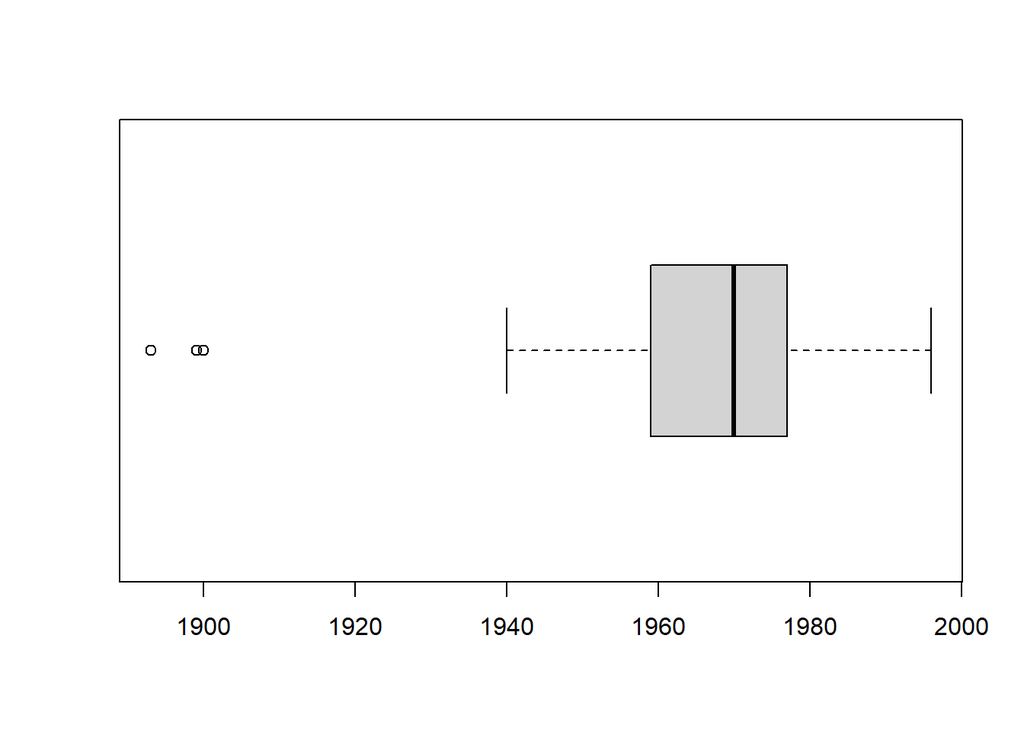

```r
boxplot(df_eda$Year_Birth,horizontal = T)
```

Criar coluna com a idade de cada cliente:

```r
# Calcular a idade do cliente
df_eda$Idade <- round(year(Sys.Date()) - df_eda$Year_Birth, digits = 2)

summary(df_eda$Idade)
```

```
   Min. 1st Qu.  Median    Mean 3rd Qu.    Max.
  28.00   47.00   54.00   55.18   65.00  131.00
```

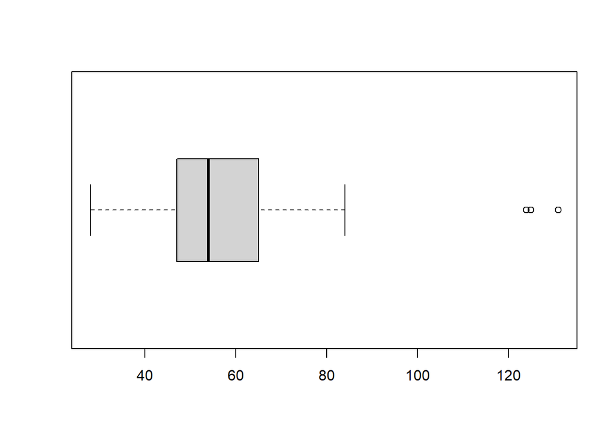

```r
boxplot(df_eda$Idade,horizontal = T)
```

```r
# Percebe-se clientes com idade muito elevada
```

Eliminar clientes com idade acima de 120 anos

```r
df_eda <- df_eda[df_eda$Idade < 120,]

summary(df_eda$Idade)
```

```
   Min. 1st Qu.  Median    Mean 3rd Qu.    Max.
  28.00   47.00   54.00   55.08   65.00   84.00
```

Verificar as 10 idades mais frequentes:

```r
# as dez idades mais frequentes
head(df_eda %>% count(Idade) %>% arrange(desc(n)),10)
```

|  | Idade | n |
| --- | --- | --- |
| 1 | 48 | 89 |
| 2 | 53 | 86 |
| 3 | 49 | 83 |
| 4 | 52 | 78 |
| 5 | 46 | 76 |
| 6 | 54 | 75 |
| 7 | 59 | 74 |
| 8 | 51 | 72 |
| 9 | 55 | 70 |
| 10 | 50 | 69 |

### Education (Nível de instrução do cliente)

Classificar o nível educacional nas classes Undergraduate e Postgraduate

```r
df_eda$Education[df_eda$Education %in% c("Basic","2n Cycle")] <- "Undergraduate"
df_eda$Education[df_eda$Education %in% c("Graduation","Master","PhD")] <- "Postgraduate"

cat("As categorias existentes em Education são:\n",
    unique(df_eda$Education),sep = "\n")
```

```
As categorias existentes em Education são:

Postgraduate
Undergraduate
```

Verificar o quantidade/percentual de clientes em cada classe:

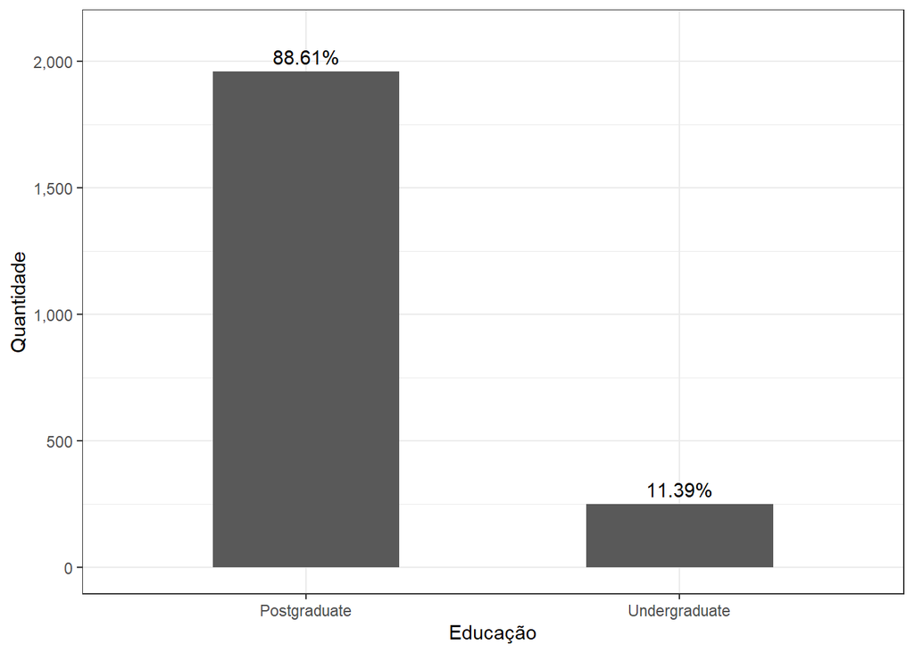

```r
# Quantidade de Undergraduate e Postgraduate
n_educacao <- df_eda %>% count(Education) %>%
  mutate(percentage= n/dim(df_eda)[1],
         percent_lab = paste0(round(percentage*100,2),"%"))

ggplot(data = n_educacao) +
  geom_col(aes(x = Education, y = n), width =0.5) +
  labs(x = "Educação",y = "Quantidade") +
  theme_bw() +
  geom_text(aes(x = Education, y = n,label=percent_lab), vjust = -0.5) +
  scale_y_continuous(limits = c(0,2100), labels = scales::comma)
```

Criar variável dummy para representar as classes Undergraduate (com 0) e Postgraduate (com 1):

```r
df_eda$Education_dummy <- ifelse(df_eda$Education == "Undergraduate", 0, 1)
```

### Marital_Status (Estado civil do cliente)

```r
unique(df_eda$Marital_Status)
```

```
[1] "Single"   "Together" "Married"  "Divorced" "Widow"    "Alone"    "Absurd"
[8] "YOLO"
```

Classificar estado civil em Alone e In Couple:

```r
# Classes da variável Marital_Status
df_eda$Marital_Status[df_eda$Marital_Status %in% c("Single","Divorced","Absurd","Widow","YOLO")] <- "Alone"
df_eda$Marital_Status[df_eda$Marital_Status %in% c("Married","Together")] <- "In couple"

cat("As classificações para o estado civil são: \n",
    unique(df_eda$Marital_Status)[1],
    unique(df_eda$Marital_Status)[2], sep = "\n")
```

```
As classificações para o estado civil são:

Alone
In couple
```

Verificar a quantidade de clientes que vivem sozinhas e com companheiros:

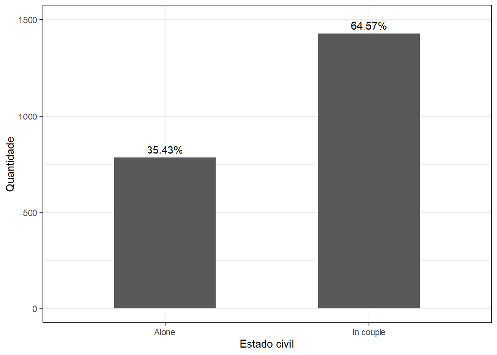

```r
# Quantidade de Alone e In couple
n_marital <- df_eda %>% count(Marital_Status) %>%
  mutate(percentage = n/dim(df_eda)[1],
          percent_lab = paste0(round(percentage*100,2),"%"))

ggplot(data = n_marital) +
  geom_col(aes(x = Marital_Status, y = n), width =0.5) +
  labs(x = "Estado civil",y = "Quantidade") +
  theme_bw() +
  geom_text(aes(x = Marital_Status, y = n,label=percent_lab), vjust = -0.5) +
  scale_y_continuous(limits = c(0,1500))
```

Criar variável dummy para representar as classes Alone (com 0) e In couple (com 1):

```r
df_eda$Marital_Status_dummy <- ifelse(df_eda$Marital_Status == "Alone", 0, 1)
```

### Income (Renda familiar anual do cliente)

```r
summary(df_eda$Income)
```

```
   Min. 1st Qu.  Median    Mean 3rd Qu.    Max.
   1730   35246   51373   52237   68487  666666
```

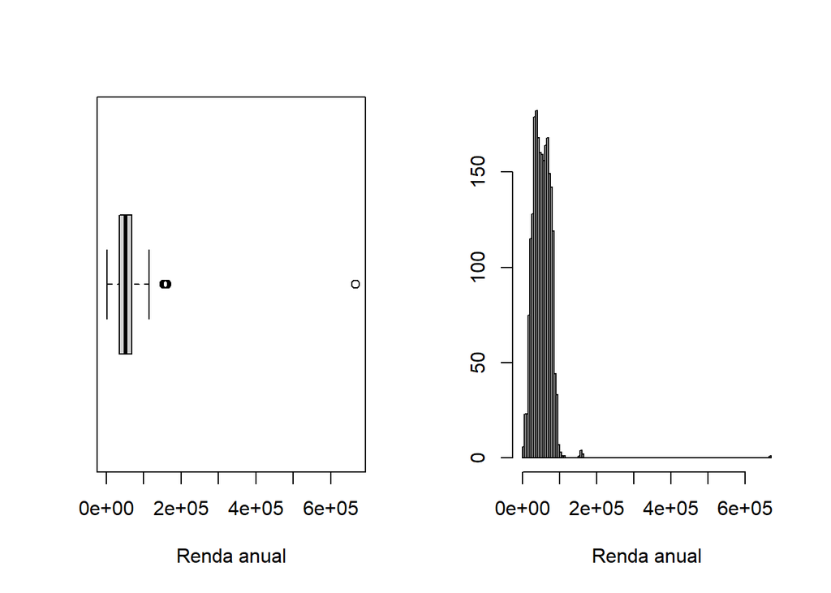

```r
par(mfrow = c(1,2))
boxplot(df_eda$Income, horizontal = T,xlab = "Renda anual")
hist(df_eda$Income,breaks = 100, main = NULL,xlab = "Renda anual",ylab=NULL)
```

```r
# Outlier!!!
```

Eliminar valor outlier!

```r
df_eda <- df_eda[df_eda$Income < 600000,]
```

```r
summary(df_eda$Income)
```

```
   Min. 1st Qu.  Median    Mean 3rd Qu.    Max.
   1730   35234   51371   51959   68487  162397
```

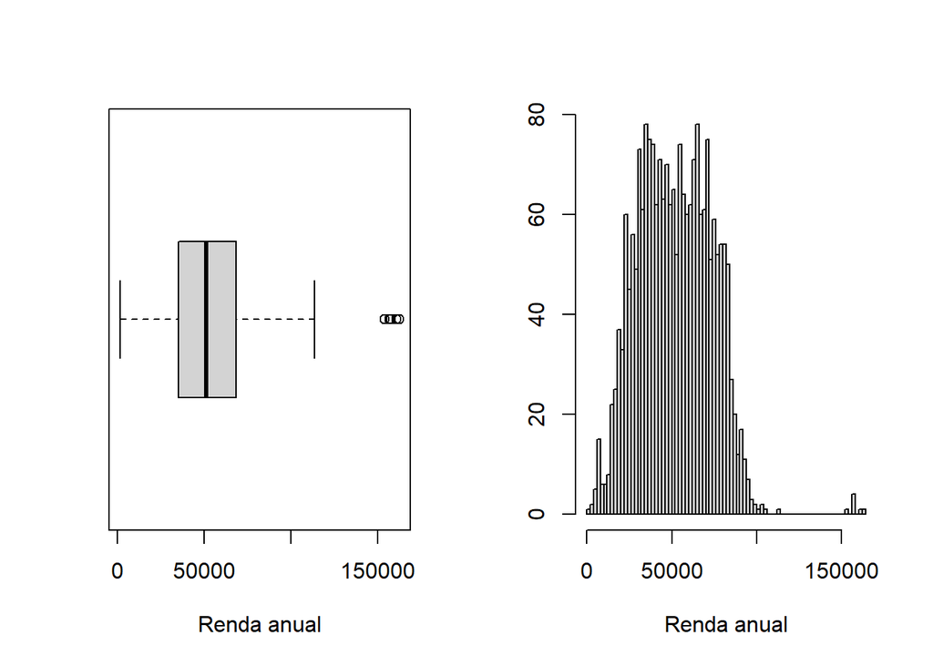

```r
par(mfrow = c(1,2))
boxplot(df_eda$Income, horizontal = T, xlab = "Renda anual")
hist(df_eda$Income,breaks = 100,xlab = "Renda anual", main = NULL,ylab=NULL)
```

### Kidhome e Teenhome (Número de crianças e adolescentes na residência do cliente)

```r
unique(df_eda$Kidhome)
```

```
[1] 0 1 2
```

```r
unique(df_eda$Teenhome)
```

```
[1] 0 1 2
```

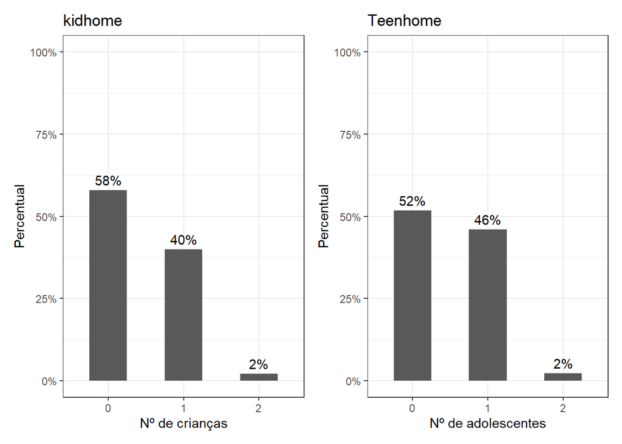

```r
percent_kidhome <- as.data.frame(prop.table(table(df_eda$Kidhome)))

g1 <- ggplot(data = percent_kidhome) +
  geom_col(aes(x = Var1, y = Freq), width =0.5) +
  labs(x="Nº de crianças",y = "Percentual", title = "kidhome") +
  scale_y_continuous(limits = c(0,1), labels = scales::percent) +
  geom_text(aes(x = Var1, y = Freq,label=paste0(round(Freq,2)*100,"%")), vjust = -0.5) +
  theme_bw()

percent_Teenhome <- as.data.frame(prop.table(table(df_eda$Teenhome)))
g2 <- ggplot(data = percent_Teenhome) +
  geom_col(aes(x = Var1, y = Freq), width =0.5) +
  labs(x="Nº de adolescentes",y = "Percentual", title = "Teenhome") +
  scale_y_continuous(limits = c(0,1), labels = scales::percent) +
  geom_text(aes(x = Var1, y = Freq,label=paste0(round(Freq,2)*100,"%")), vjust = -0.5) +
  theme_bw()

(g1+g2)
```

Calcular o número de filhos por cliente e verificar o valor percentual de cada uma das quantidades:

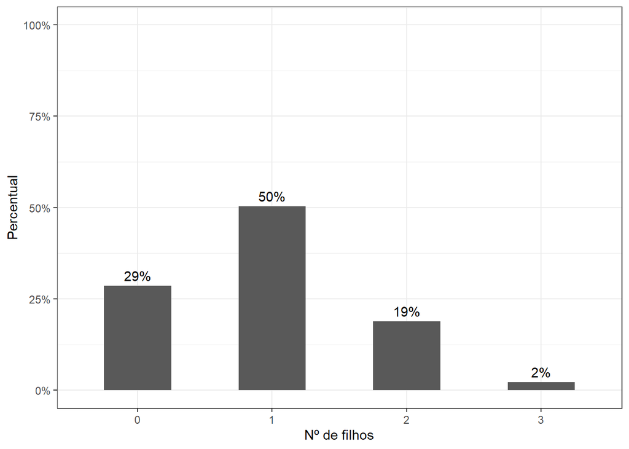

```r
df_eda$N_Children <- df_eda$Kidhome + df_eda$Teenhome
percent_N_Children <- as.data.frame(prop.table(table(df_eda$N_Children)))

ggplot(data = percent_N_Children) +
  geom_col(aes(x = Var1, y = Freq), width =0.5) +
  labs(x="Nº de filhos",y = "Percentual") +
  scale_y_continuous(limits = c(0,1),labels = scales::percent_format(scale = 100,accuracy =5L)) +
  geom_text(aes(x = Var1, y = Freq,label=paste0(round(Freq,2)*100,"%")), vjust = -0.5) +
  theme_bw()
```

### Dt_Customer (Data do cadastro do cliente na empresa)

```r
df_eda$Dt_Customer <- as_date(dmy(df_eda$Dt_Customer))
class(df_eda$Dt_Customer)
```

```
[1] "Date"
```

```r
summary(df_eda$Dt_Customer)
```

```
        Min.      1st Qu.       Median         Mean      3rd Qu.         Max.
"2012-07-30" "2013-01-16" "2013-07-08" "2013-07-10" "2013-12-31" "2014-06-29"
```

Quantidade de dias desde a data da inscrição na empresa até o dia atual:

```r
df_eda$Dt_inscricao_ate_atual <- Sys.Date() - df_eda$Dt_Customer
df_eda$Dt_inscricao_ate_atual <- as.numeric(df_eda$Dt_inscricao_ate_atual)

summary(df_eda$Dt_inscricao_ate_atual)
```

```
   Min. 1st Qu.  Median    Mean 3rd Qu.    Max.
   3823    4003    4179    4177    4352    4522
```

### Recency (Quantidade de dias desde a última compra do cliente)

```r
summary(df_eda$Recency)
```

```
   Min. 1st Qu.  Median    Mean 3rd Qu.    Max.
   0.00   24.00   49.00   49.02   74.00   99.00
```

### MntWines, MntFruits, MntMeatProducts, MntFishProducts, MntSweetProducts e MntGoldProds

```r
summary(df_eda$MntWines)
```

```
   Min. 1st Qu.  Median    Mean 3rd Qu.    Max.
    0.0    24.0   175.5   305.3   505.0  1493.0
```

```r
summary(df_eda$MntFruits)
```

```
   Min. 1st Qu.  Median    Mean 3rd Qu.    Max.
   0.00    2.00    8.00   26.33   33.00  199.00
```

```r
summary(df_eda$MntMeatProducts)
```

```
   Min. 1st Qu.  Median    Mean 3rd Qu.    Max.
    0.0    16.0    68.0   167.0   232.2  1725.0
```

```r
summary(df_eda$MntFishProducts)
```

```
   Min. 1st Qu.  Median    Mean 3rd Qu.    Max.
   0.00    3.00   12.00   37.65   50.00  259.00
```

```r
summary(df_eda$MntSweetProducts)
```

```
   Min. 1st Qu.  Median    Mean 3rd Qu.    Max.
   0.00    1.00    8.00   27.05   33.00  262.00
```

```r
summary(df_eda$MntGoldProds)
```

```
   Min. 1st Qu.  Median    Mean 3rd Qu.    Max.
   0.00    9.00   24.50   43.93   56.00  321.00
```

Calcular a quantidade total gasto em produtos:

```r
df_eda$Gasto_total <- df_eda$MntWines + df_eda$MntFruits + df_eda$MntMeatProducts +
  df_eda$MntFishProducts + df_eda$MntSweetProducts + df_eda$MntGoldProds

summary(df_eda$Gasto_total)
```

```
   Min. 1st Qu.  Median    Mean 3rd Qu.    Max.
    5.0    69.0   397.0   607.3  1048.0  2525.0
```

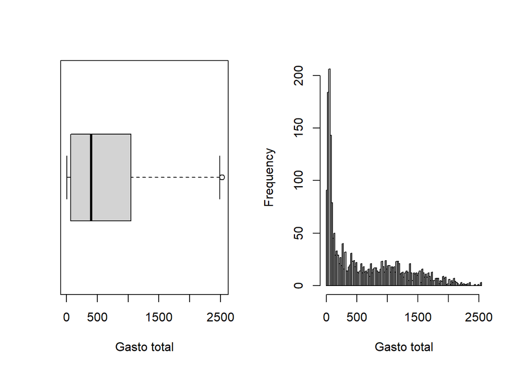

```r
par(mfrow = c(1,2))
boxplot(df_eda$Gasto_total,horizontal = T,xlab ="Gasto total")
hist(df_eda$Gasto_total, breaks = 100,xlab ="Gasto total", main = NULL)
```

### NumDealsPurchases (Número de compras feitas com desconto)

```r
summary(df_eda$NumDealsPurchases)
```

```
   Min. 1st Qu.  Median    Mean 3rd Qu.    Max.
  0.000   1.000   2.000   2.325   3.000  15.000
```

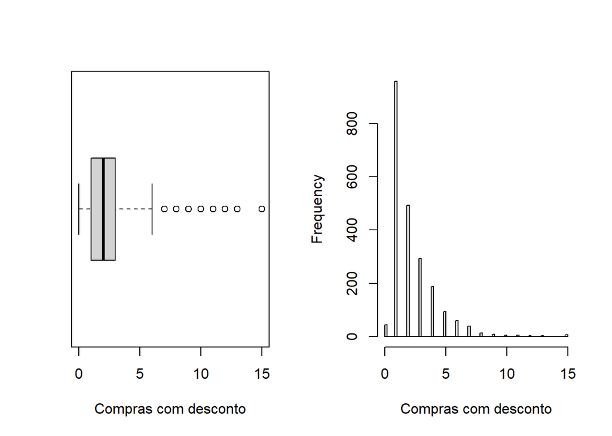

```r
par(mfrow = c(1,2))
boxplot(df_eda$NumDealsPurchases, horizontal = T,xlab ="Compras com desconto")
hist(df_eda$NumDealsPurchases, breaks = 100,xlab ="Compras com desconto", main = NULL)
```

### NumWebPurchases, NumCatalogPurchases e NumStorePurchases

Número total de compras por cliente:

```r
df_eda$Numero_compras <- df_eda$NumWebPurchases + df_eda$NumCatalogPurchases + df_eda$NumStorePurchases

summary(df_eda$Numero_compras)
```

```
   Min. 1st Qu.  Median    Mean 3rd Qu.    Max.
   0.00    6.00   12.00   12.57   18.25   32.00
```

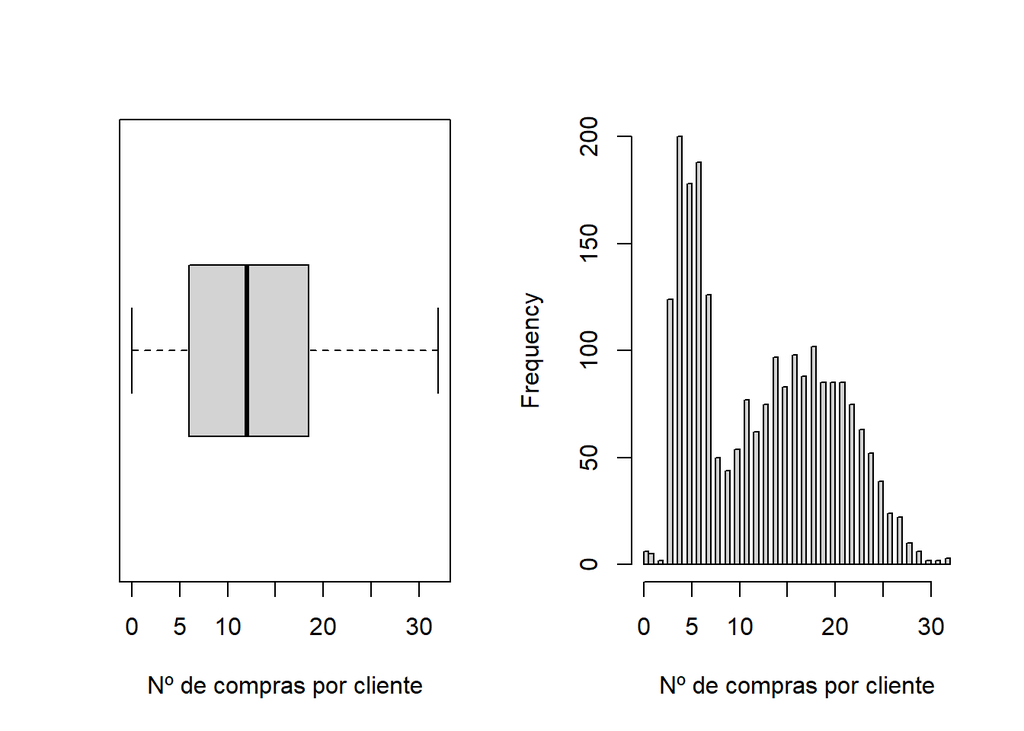

```r
par(mfrow = c(1,2))
boxplot(df_eda$Numero_compras,xlab ="Nº de compras por cliente", horizontal = T)
hist(df_eda$Numero_compras, breaks = 100,xlab ="Nº de compras por cliente", main = NULL)
```

Verificar a quantidade de compras feitas em cada local de venda:

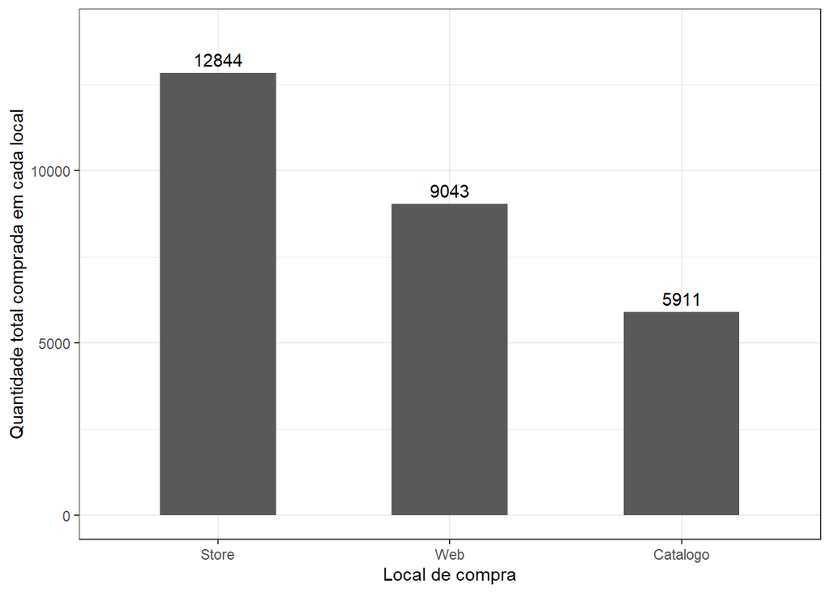

```r
local <- c("Web","Catalogo","Store")
valor <- c(sum(df_eda$NumWebPurchases),
           sum(df_eda$NumCatalogPurchases),
           sum(df_eda$NumStorePurchases))
local_vendas <- data.frame(local,valor)
local_vendas$local <- factor(local_vendas$local, levels = c("Catalogo","Web","Store"))

ggplot(data = local_vendas) +
  geom_col(aes(x = reorder(local,-valor), y = valor), width = 0.5) +
  labs(x = "Local de compra",y = "Quantidade total comprada em cada local") +
  theme_bw() + geom_text(aes(x = local, y = valor,label=valor), vjust = -0.5) +
  scale_y_continuous(limits = c(0,14000))
```

### NumWebVisitsMonth (Número de visitas ao site da empresa no último mês)

```r
summary(df_eda$NumWebVisitsMonth)
```

```
   Min. 1st Qu.  Median    Mean 3rd Qu.    Max.
  0.000   3.000   6.000   5.321   7.000  20.000
```

### AcceptedCmp1, AcceptedCmp2, AcceptedCmp3, AcceptedCmp4, AcceptedCmp5 e Response

```r
unique(df_eda$AcceptedCmp1)
```

```
[1] 0 1
```

```r
unique(df_eda$AcceptedCmp2)
```

```
[1] 0 1
```

```r
unique(df_eda$AcceptedCmp3)
```

```
[1] 0 1
```

```r
unique(df_eda$AcceptedCmp4)
```

```
[1] 0 1
```

```r
unique(df_eda$AcceptedCmp5)
```

```
[1] 0 1
```

```r
unique(df_eda$Response)
```

```
[1] 1 0
```

Calcular o número de campanhas aceitas por cada cliente:

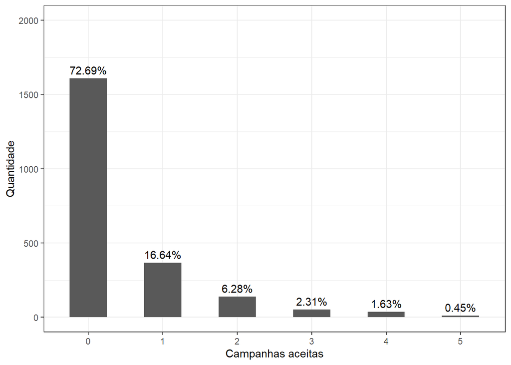

```r
df_eda$Num_campaign_acc <- df_eda$AcceptedCmp1 + df_eda$AcceptedCmp2 +
  df_eda$AcceptedCmp3 + df_eda$AcceptedCmp4 + df_eda$AcceptedCmp5 + df_eda$Response



n_campaign_acc <- df_eda %>% count(Num_campaign_acc) %>% mutate(perc_camp = n/sum(n),
                                                                 perc_lab = paste0(round(perc_camp*100,2),"%"))
n_campaign_acc$Num_campaign_acc <-  as.factor(n_campaign_acc$Num_campaign_acc)

ggplot(data = n_campaign_acc) +
  geom_col(aes(x = Num_campaign_acc, y = n), width = 0.5) +
  labs(x = "Campanhas aceitas",y = "Quantidade") +
  theme_bw() + geom_text(aes(x = Num_campaign_acc, y = n,label=perc_lab), vjust = -0.5) +
  scale_y_continuous(limits = c(0,2000))
```

### Complain (1 se o cliente reclamou nos últimos 2 anos, 0 caso contrário)

```r
unique(df_eda$Complain)
```

```
[1] 0 1
```

```r
cat("Foram feitas um total de",sum(df_eda$Complain),"reclamações.")
```

```
Foram feitas um total de 20 reclamações.
```

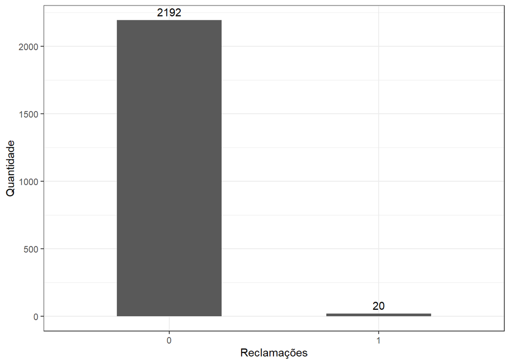

```r
n_complain <- df_eda %>% count(Complain)
n_complain$Complain <-  as.factor(n_complain$Complain)

ggplot(data = n_complain) +
  geom_col(aes(x = Complain, y = n), width = 0.5) +
  labs(x = "Reclamações",y = "Quantidade") +
  geom_text(aes(x = Complain, y = n,label=n), vjust = -0.5) +
  theme_bw()
```

## Calcular o valor médio por compra

```r
# Eliminas valor de compra igual a zero (6 linhas)
df_eda <- df_eda[df_eda$Numero_compras > 0,]

df_eda$Valor_medio_de_compra <- round(df_eda$Gasto_total/df_eda$Numero_compras,
                                       digits = 2)
```

## Análise Bivariadas

### Total de gasto por nível educacional

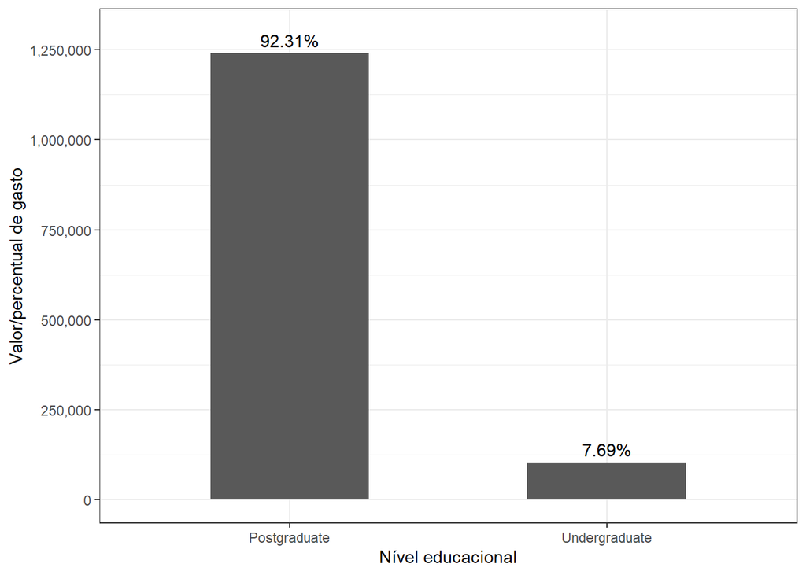

```r
Gst_niv_educ <- df_eda %>% group_by(Education) %>% summarise(Gasto_Edu = sum(Gasto_total)) %>%
  mutate(perc_gasto = Gasto_Edu/sum(Gasto_Edu),
         perc_lab = paste0(round(perc_gasto*100,2),"%"))

ggplot(data = Gst_niv_educ) +
  geom_col(aes(x = Education,y = Gasto_Edu), width = 0.5) +
  labs(x="Nível educacional",y = "Valor/percentual de gasto") +
  theme_bw() + geom_text(aes(x = Education,y = Gasto_Edu,label=perc_lab), vjust = -0.5) +
  scale_y_continuous(limits = c(0,1300000), breaks = seq(0,1300000,250000),
                     labels = scales::comma)
```

### Valor médio de compra por nível educacional

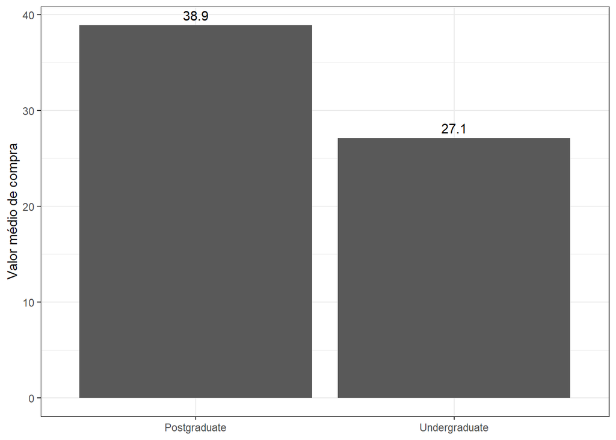

```r
ggplot(data = df_eda %>% group_by(Education) %>%
  summarise(media = mean(Valor_medio_de_compra))) +
  geom_col(aes(x = Education, y = media),linewidth=1.8) +
  labs(x=NULL,y="Valor médio de compra") +
  geom_text(aes(x = Education,y = media,label= paste0(round(media,1))), vjust = -0.5) +
  theme_bw()
```

### Total de gasto por estado civil

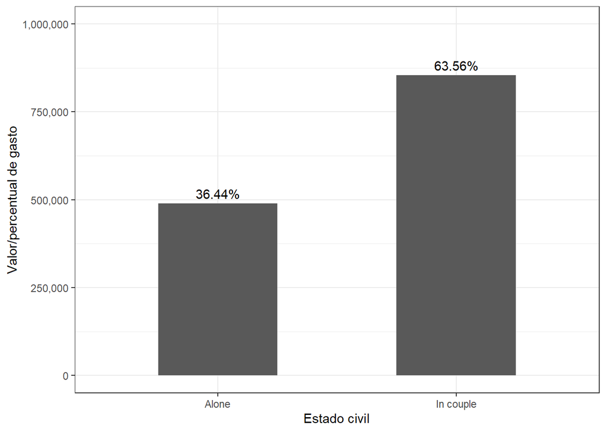

```r
Gst_est_civ <- df_eda %>% group_by(Marital_Status) %>% summarise(Gasto_Marital = sum(Gasto_total)) %>%
  mutate(perc_gasto = Gasto_Marital/sum(Gasto_Marital),
         perc_lab = paste0(round(perc_gasto*100,2),"%"))

ggplot(data = Gst_est_civ) +
  geom_col(aes(x = Marital_Status,y = Gasto_Marital), width = 0.5) +
  labs(x="Estado civil",y = "Valor/percentual de gasto") +
  theme_bw()  + geom_text(aes(x = Marital_Status,y = Gasto_Marital,label=perc_lab), vjust = -0.5) +
  scale_y_continuous(limits = c(0,1000000), labels = scales::comma)
```

### Valor médio de compra por estado civil

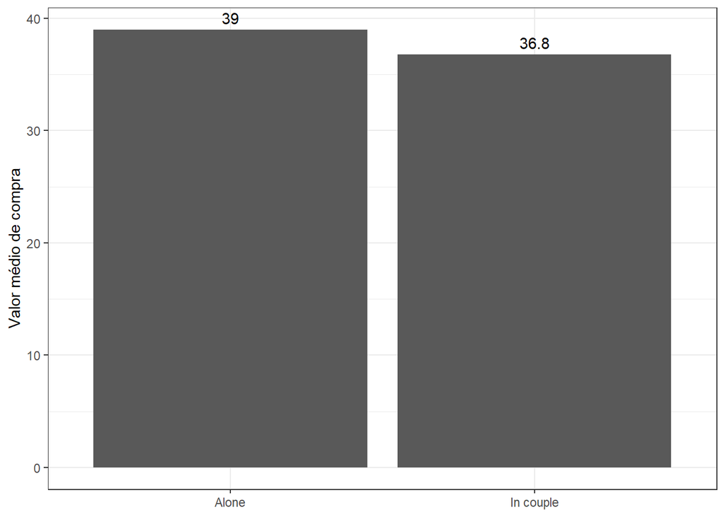

```r
ggplot(data = df_eda %>% group_by(Marital_Status) %>%
  summarise(media = mean(Valor_medio_de_compra))) +
  geom_col(aes(x = Marital_Status, y = media),linewidth=1.8) +
  labs(x=NULL,y="Valor médio de compra") +
  geom_text(aes(x = Marital_Status,y = media,label= paste0(round(media,1))), vjust = -0.5) +
  theme_bw()
```

### Total de gasto por número de filhos

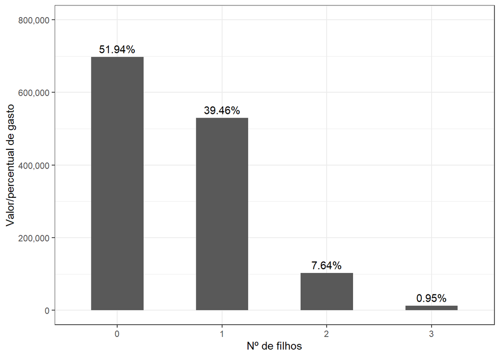

```r
Gst_n_Children <- df_eda %>% group_by(N_Children) %>% summarise(Gasto_Child = sum(Gasto_total)) %>%
  mutate(perc_gasto = Gasto_Child/sum(Gasto_Child),
         perc_lab = paste0(round(perc_gasto*100,2),"%"))
Gst_n_Children$N_Children <- factor(Gst_n_Children$N_Children)

ggplot(data = Gst_n_Children) +
  geom_col(aes(x = N_Children,y = Gasto_Child), width = 0.5) +
  labs(x = "Nº de filhos",y = "Valor/percentual de gasto") +
  theme_bw()  + geom_text(aes(x = N_Children,y = Gasto_Child,label=perc_lab), vjust = -0.5) +
  scale_y_continuous(limits = c(0,800000), labels = scales::comma)
```

### Valor médio de compra por número de filhos

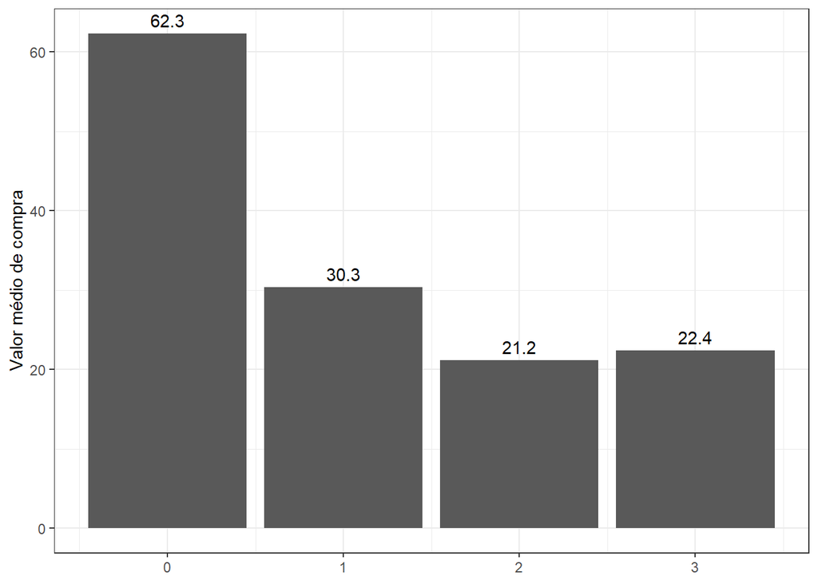

```r
ggplot(data = df_eda %>% group_by(N_Children) %>%
  summarise(media = mean(Valor_medio_de_compra))) +
  geom_col(aes(x = N_Children, y = media),linewidth=1.8) +
  labs(x=NULL,y="Valor médio de compra") +
  geom_text(aes(x = N_Children,y = media,label= paste0(round(media,1))), vjust = -0.5) +
  theme_bw()
```

### Total de gasto dado o número de campanhas aceitas

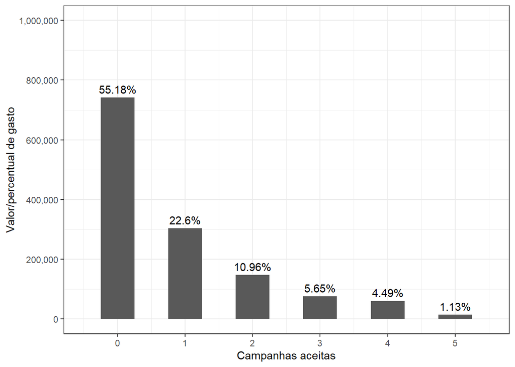

```r
# gasto pelo número de campanhas aceitas
Gst_campaign_acc <- df_eda %>%
  group_by(Num_campaign_acc) %>% summarise(Gasto_camp_acc = sum(Gasto_total)) %>%
  mutate(perc_gasto_camp = round((Gasto_camp_acc/sum(Gasto_camp_acc))*100,2),
         perc_lab = paste0(perc_gasto_camp,"%"))

ggplot(data = Gst_campaign_acc) +
  geom_col(aes(x = Num_campaign_acc,y = Gasto_camp_acc), width = 0.5) +
  labs(x = "Campanhas aceitas",y = "Valor/percentual de gasto") +
  theme_bw() + geom_text(aes(x = Num_campaign_acc,y = Gasto_camp_acc,label = perc_lab), vjust = -0.5) +
  scale_y_continuous(limits = c(0,1000000), breaks = c(0,200000,400000,600000,800000,1000000),
                     labels = scales::comma) +
  scale_x_continuous(limits = c(-0.5,5.5), breaks = seq(0,5,1))
```

### Valor médio de compra dado o número de campanhas aceitas

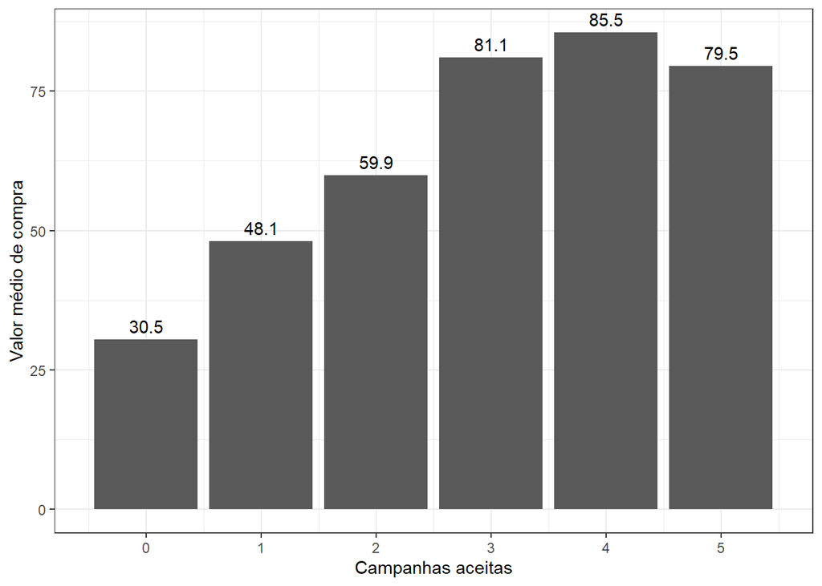

```r
ggplot(data = df_eda %>% group_by(Num_campaign_acc) %>%
  summarise(media = mean(Valor_medio_de_compra))) +
  geom_col(aes(x = Num_campaign_acc, y = media),size=1.8) +
  labs(x="Campanhas aceitas",y="Valor médio de compra") +
  geom_text(aes(x = Num_campaign_acc,y = media,label= paste0(round(media,1))), vjust = -0.5) +
  scale_x_continuous(limits = c(-0.5,5.5), breaks = seq(0,5,1)) +
  theme_bw()
```

### Quantidade de observações por classes

```r
df_eda %>% group_by(Education) %>% count()
```

| Education | n |
| --- | --- |
| Postgraduate | 1954 |
| Undergraduate | 252 |

```r
df_eda %>% group_by(Marital_Status) %>% count()
```

| Marital_Status | n |
| --- | --- |
| Alone | 780 |
| In couple | 1426 |

```r
df_eda %>% group_by(N_Children) %>% count()
```

| N_Children | n |
| --- | --- |
| 0 | 628 |
| 1 | 1113 |
| 2 | 415 |
| 3 | 50 |

### Dispersão do valor médio de compra pela renda anual do cliente

- Disciminando por Nível Educacional

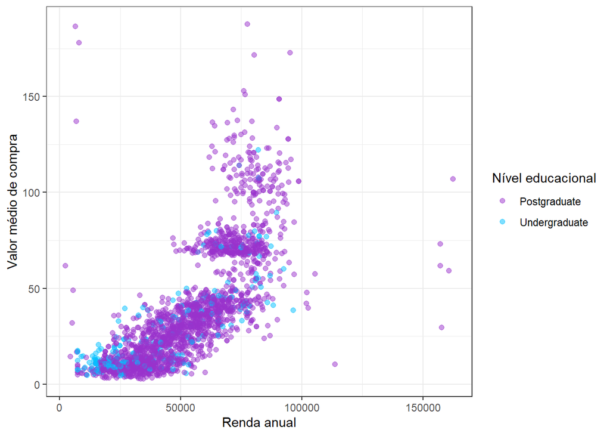

```r
ggplot(data = df_eda) +
  geom_point(aes(x = Income, y = Valor_medio_de_compra, color = Education),alpha=0.5,size=1.8) +
  labs(x="Renda anual",y="Valor médio de compra") +
  theme_bw() +
  scale_colour_manual("Nível educacional", values = c("darkorchid","deepskyblue1"))
```

- Disciminando por quantidade de filhos

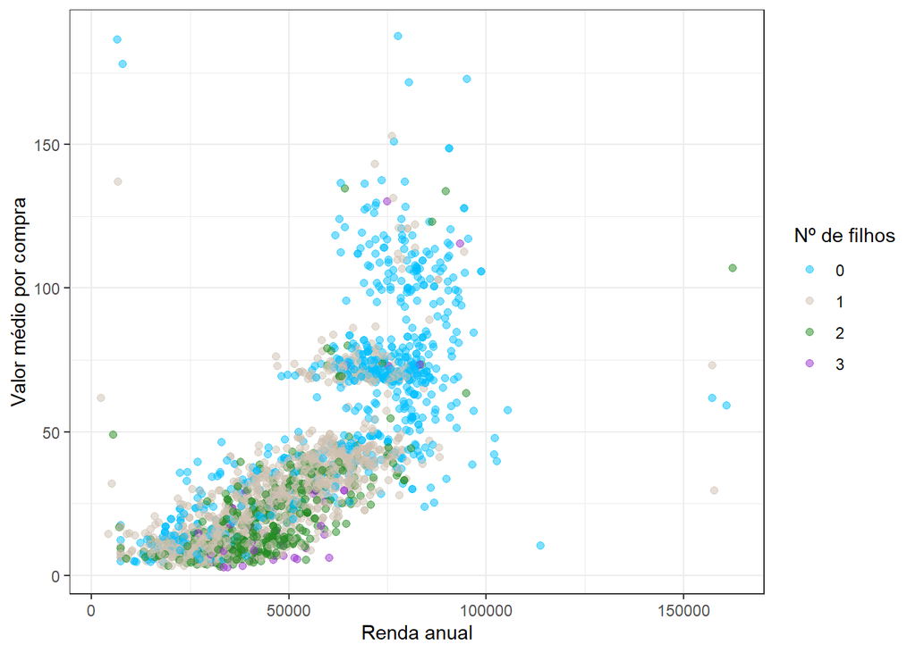

```r
df_eda$N_Children <- factor(df_eda$N_Children)

ggplot(data = df_eda) +
  geom_point(aes(x = Income, y = Valor_medio_de_compra, color = N_Children),alpha=0.5,size=1.8) +
  labs(x="Renda anual",y="Valor médio por compra") +
  theme_bw() +
  scale_colour_manual("Nº de filhos", values = c("deepskyblue1","antiquewhite3","forestgreen","darkorchid"))
```

### Dispersão do Gasto total em compras pela renda anual do cliente

- Disciminando por quantidade de filhos

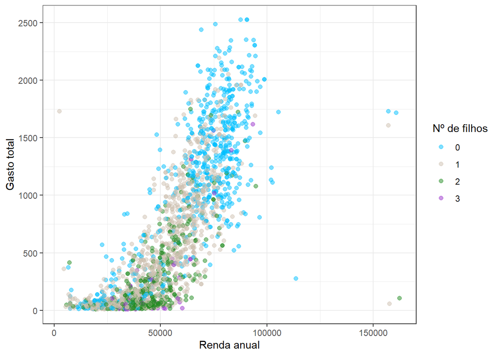

```r
ggplot(data = df_eda) +
  geom_point(aes(x = Income, y =  Gasto_total, color = N_Children),alpha=0.5,size=1.8) +
  labs(x="Renda anual",y="Gasto total") +
  theme_bw() +
  scale_colour_manual("Nº de filhos", values = c("deepskyblue1","antiquewhite3","forestgreen","darkorchid"))
```

## Correlação entre variáveis

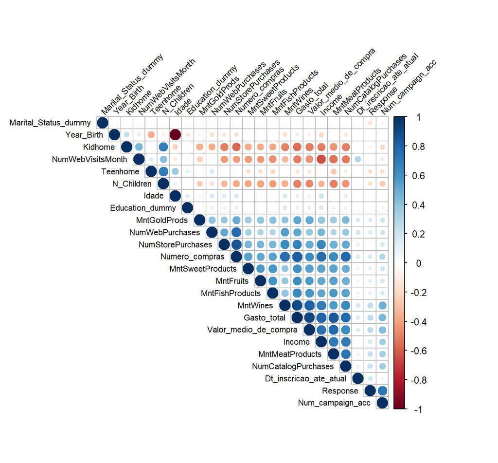

```r
df_eda$N_Children <- as.integer(df_eda$N_Children)

df_cor <- df_eda[,sapply(df_eda, mode) == "numeric"] %>%
  select(-c("ID","Dt_Customer","Recency","Complain",
            "AcceptedCmp1","AcceptedCmp2","AcceptedCmp3",
            "AcceptedCmp4","AcceptedCmp5","NumDealsPurchases")) %>% scale()

correlacao <- cor(df_cor)
corrplot(correlacao, type = "upper", order = "hclust",
         tl.col = "black", tl.srt = 45, tl.cex = 0.7)
```